# Spatial Analysis of Toronto City

## Introduction

### In the following analysis, I have opted for various Machine Learning techniques to analyze the geographic typology and the socio-economic environment of Toronto city. I have done this by analyzing a dataset that houses different information about Toronto. To do this efficiently I have also downloaded two external datasets - one having the location of different retirement homes, and the other having the location of different skill development agencies for youths. This has helped me to reach the conclusion stated below

```python
import geopandas # used to extend the datatypes used by pandas to allow spatial operations on geometric types
import pandas #pandas is mainly used for data analysis
import contextily as ctx #contextily is used to add a basemap underneath the data points.
from pysal.viz import mapclassify #mapclassify implements a family of classification schemes for choropleth maps. It determines the number of classes, and the assignment of observations to those classes
from pysal.lib import weights #used to calculate the spatial weights matrix.
import seaborn as sns #Seaborn is a Python data visualization library based on matplotlib. It provides a high-level interface for drawing attractive and informative statistical graphics
import matplotlib.pyplot as plt #Matplotlib is a plotting library for the Python programming language and its numerical mathematics extension NumPy.
from sklearn import cluster #The sklearn library contains a lot of efficient tools for machine learning and statistical modeling including classification, regression, clustering and dimensionality reduction
```

```python
#read geopackage file
#neis is an object in which the data of the geopackage files are stored
neis = geopandas.read_file("https://darribas.org/gds_course/_downloads/a2bdb4c2a088e602c3bd6490ab1d26fa/toronto_socio-economic.gpkg")
```

```python
# Dataset for supporting second variable
#ab is the object in which the data of the geopackage files are stored
ab=geopandas.read_file("C:/Users/Souvik/Desktop/Geographic Data Science/Retirement Homes.gpkg")
```

```python
# Dataset for supporting first variable
#ab is the object in which the data of the geopackage files are stored
br=geopandas.read_file("C:/Users/Souvik/Desktop/Geographic Data Science/Employment Resources.gpkg")
```

```python
#db is the object in which the data of the comma-seperated values file is stored
db=pandas.read_csv("https://darribas.org/gds_course/_downloads/8944151f1b7df7b1f38b79b7a73eb2d0/toronto_socio-economic_vars.csv")
```

```python
#The coordinate referencing system or crs is used to represnt three-dimesional object on a two dimensional plane.
#To transform data into latitudes and longitudes we use EPSG code 4326.
neis.crs = "EPSG:4326"
```

## Part I

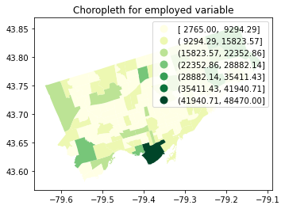

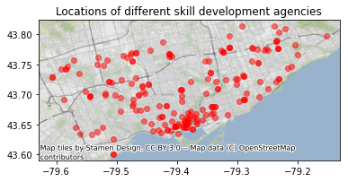

```python
#Inspiration for designing choropleths(https://medium.com/using-specialist-business-databases/creating-a-choropleth-map-using-geopandas-and-financial-data-c76419258746)
ax=neis.plot(column="employed", #choosing the first variable employed and finding out its choropleths
         scheme="equalinterval", #choosing the equalinterval scheme which partitions the bins in such an order that the number of counts are in a decreasing order
         k=7, #choosing the number of bins to be 7
         cmap="YlGn", #Choosing the colour green from the Color Brewer
         legend="True" #legend is set to True so that the different bins are showed in the map.

       )
ax.set_title("Choropleth for employed variable")#setting the title of the map


# Plotting the polygons
ax = br.plot(alpha=0.5, color='red'); #alpha value depicts the opaqueness of the dots. Red is the color chosen for the dots
ctx.add_basemap(ax, crs=br.crs) # adding basemap
ax.set_title("Locations of different skill development agencies")#setting the title for the basemap induced map
```

```python
# Creating the spatial weights matrix
%time w = weights.Queen.from_dataframe(neis, idVariable= "_id")
#spatial weights matrix is made using the _id column, as the spatial weights matrix just shows the neighbours of polygons not neighbours of the specific variable.
```

```
Wall time: 479 ms
```

```python
# Row standardize the matrix
w.transform = 'R'
```

To make the operations easier we make a standardized version of the variable which we are working with. This can be done by subtracting the average value and divide by the standard deviation of each observation of the column.

```python
neis['employed_std'] = (neis['employed'] - neis['employed'].mean()) / neis['employed'].std()
```

```python
#We create the spatial lag of the variable
neis['w_employed_std'] = weights.lag_spatial(w, neis['employed_std'])
```

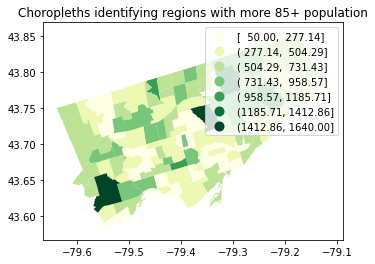

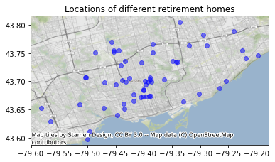

```python
ax=neis.plot(column="pop_85+_yearsold", #choosing the second variable pop_85+_yearsold and finding out its choropleths
        scheme="equalinterval", #choosing the equalinterval scheme which partitions the bins in such an order that the number of counts are in a decreasing order
         k=7, #choosing the number of bins to be 7
        cmap="YlGn", #Choosing the colour green from the Color Brewer
        legend="True" #legend is set to True so that the different bins are showed in the map.
       )

ax.set_title("Choropleths identifying regions with more 85+ population") #setting the title of the first  map



import contextily as ctx #contextily is used to add a basemap underneath the data points.
# Plot polygons
ax = ab.plot(alpha=0.5, color='blue'); #alpha denotes the opaqueness of the dots. The color of the dots are blue
# Adding background map, expressing target CRS so the basemap can be

ctx.add_basemap(ax, crs=ab.crs) # adding basemap
ax.set_title("Locations of different retirement homes") #setting the title of the second map
```

To make the operations easier we make a standardized version of the variable which we are working with. This can be done by subtracting the average value and divide by the standard deviation of each observation of the column

```python
neis['pop_85+_std'] = (neis['pop_85+_yearsold'] - neis['pop_85+_yearsold'].mean()) / neis['pop_85+_yearsold'].std()
```

```python
#We create the spatial lag of the variable
neis['w_pop_85+_std'] = weights.lag_spatial(w, neis['pop_85+_std'])
```

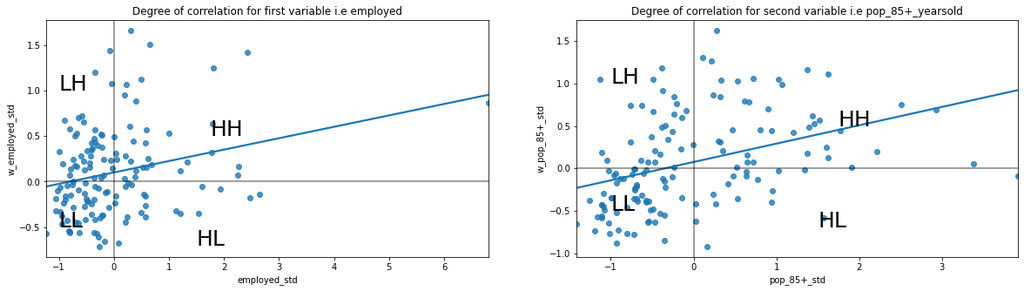

```python
f, axs = plt.subplots(1,2, figsize=(20, 5))#we have one row of pictures and two colomns that represent 1,2. The size of the figures are 20 X 5
# Plot values
sns.regplot(x='employed_std', y='w_employed_std', data=neis, ci=None,ax=axs[0]) #x axis holds 'employed_std' and y axis holds 'w_employed_std' and the plot is made of the employed variable from the data stored in neis object

# Add vertical and horizontal lines
axs[0].axvline(0, c='k', alpha=0.5)# axvline() function from pyplot module is used to add vertical lines across the axes of the plot
axs[0].axhline(0, c='k', alpha=0.5)# axhline() funtion from pyplot module is used to add horizontsasl lines across the axes of the plot
axs[0].text(1.75, 0.5, "HH", fontsize=25) #Setting the Location of text 'HH' in plot and fontsize 25
axs[0].text(1.5, -0.7, "HL", fontsize=25) #Setting the locationg of text 'HL' in plot and fontsize 25
axs[0].text(-1, 1, "LH", fontsize=25) #Setting the location of text 'LH' in plot and fontsize 25
axs[0].text(-1, -0.5, "LL", fontsize=25) #Settign the location of text 'LL' in plot and fontsize 25
axs[0].set_title("Degree of correlation for first variable i.e employed")#settign the title of first figure from left
# Display
plt.show()

#Inspiration for bringing images side by side(https://stackoverflow.com/questions/17079279/how-is-axis-indexed-in-numpys-array)


# Plot values

sns.regplot(x='pop_85+_std', y='w_pop_85+_std', data=neis, ci=None, ax=axs[1]) #x asix holds 'pop_85+_std' and y axis holds 'w_pop_85+_std' and the plot is made of the employed variable from the data stored in neis object
# Add vertical and horizontal lines
axs[1].axvline(0, c='k', alpha=0.5)# axvline() function from pyplot module is used to add vertical lines across the axes of the plot
axs[1].axhline(0, c='k', alpha=0.5)# axhline() funtion from pyplot module is used to add horizontsasl lines across the axes of the plot
axs[1].text(1.75, 0.5, "HH", fontsize=25)#Setting the Location of text 'HH' in plot and fontsize 25
axs[1].text(1.5, -0.7, "HL", fontsize=25)#Setting the locationg of text 'HL' in plot and fontsize 25
axs[1].text(-1, 1, "LH", fontsize=25)#Setting the location of text 'LH' in plot and fontsize 25
axs[1].text(-1, -0.5, "LL", fontsize=25)#Settign the location of text 'LL' in plot and fontsize 25
axs[1].set_title("Degree of correlation for second variable i.e pop_85+_yearsold")#settign the title of first figure from left
# Display
plt.show()
```

The first figure from the left named "Degree of correlation for first variable i.e. employed" shows a positive correlation. But the data points are denser in the low -low region indicating that similar low values are together hence indicating more number of low employment regions. Also, the number of data points in the low-high region is more indicating clusters of dissimilar values or regions with a mixed degree of employment. There are also data points with high high regions meaning high employment areas. But they are denser in the low low region but not evenly spread out in the High high region indicating more low employment regions.

## PART-II

```python
#These are the parameters which I have chosen to indentify the different kinds of neighborhoods
parameters=['bedrooms_4+','bedrooms_3','employed','pop_25-54_yearsold','deg_medics']
```

### I have chosen the above mentioned parameters to indentify this type of typology as these will give me an idea of the living standard of the people living in Toronto. Hence this will help me to identify the regions which are poverty stricken.

```python
kmeans5 = cluster.KMeans(n_clusters=5, random_state=12345) #Using k means clusterig technique to make 5 clusters. Random state is used to make a random slection of data points as k means selects centroids from random region and finds the euclidean distance in them.
k5cls = kmeans5.fit(neis[parameters])#parameters hard-coded above is set to fit in those clusters
neis['k5cls'] = k5cls.labels_ #all the combination of different parameters are assigned different numbers. Each number represents a different category, so two observations with the same number belong to same group
```

In the next histogram I have plotted each variable in the parameter list with every other variable. We can see that there is a positive coorelation with the employed variable and the bedrooms_4+, bedrooms_3 and medical degree holder. Hence with regions of high employment there are more number of localities close by having higher number of bedrooms and higher number of people receiving better education

I have made 5 clusters of the variables in the paramater list. The last map shows the areas with these clusters

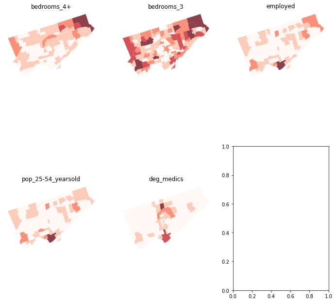

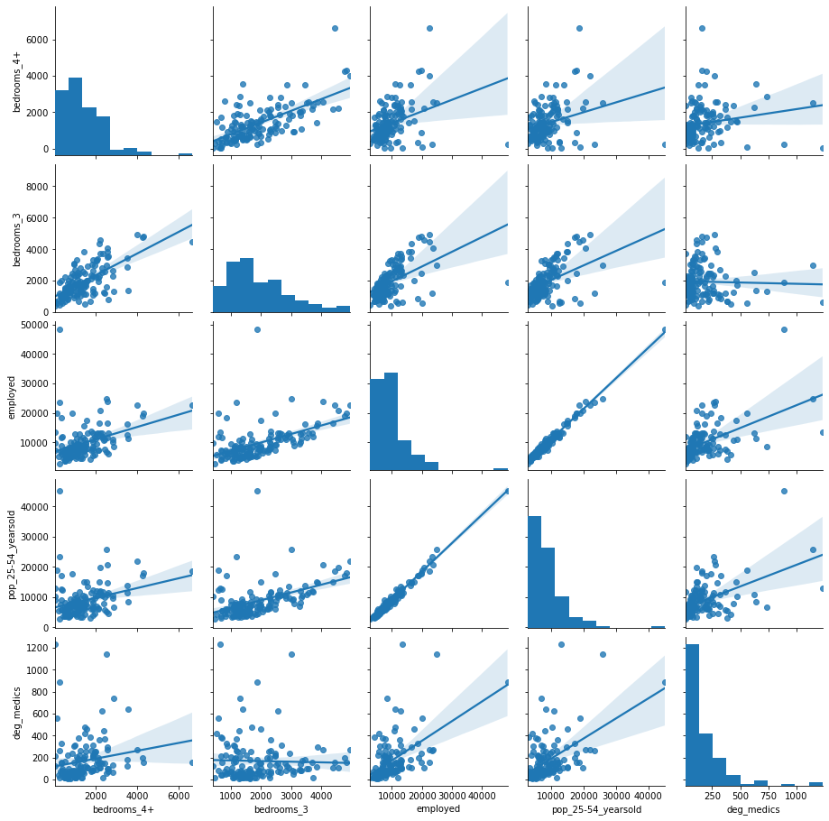

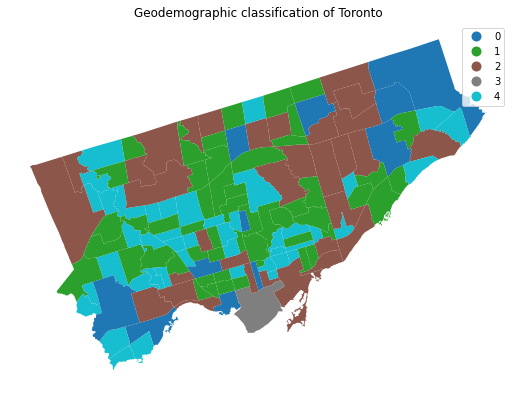

```python
# Create figure and axes (this time it's 6, arranged 2 by 3)
f, axs = plt.subplots(nrows=2, ncols=3, figsize=(12, 12))#No of rows for first histogram is 2 and columns is 3. The size of the figures are 12 X 12
# Make the axes accessible with single indexing
axs = axs.flatten()
# Start the loop over all the variables of interest
for i, col in enumerate(parameters):
    # select the axis where the map will go
    ax = axs[i]
    # Plot the map
    neis.plot(column=col, ax=ax, scheme='EqualInterval', \
             linewidth=0, cmap='Reds', alpha=0.75)
    # Remove axis clutter
    ax.set_axis_off()
    # Set the axis title to the name of variable being plotted
    ax.set_title(col)
# Display the figure
plt.show()

_ = sns.pairplot(neis[parameters], kind='reg', diag_kind='hist')


# Setup figure and ax
f, ax = plt.subplots(1, figsize=(9, 9))
# Plot unique values choropleth including a legend and with no boundary lines
neis.plot(column='k5cls', categorical=True, legend=True, linewidth=0, ax=ax)
# Remove axis
ax.set_axis_off()
# Add title
plt.title('Geodemographic classification of Toronto')
# Display the map
plt.show()
```

The table below shows the different clusters and the mean values of each variable. So if one wants to settle in an area of high employment he or she might look out for areas falling in the fourth cluster

```python
# Calculate the mean by group
k5means = neis.groupby('k5cls')[parameters].mean()
# Show the table transposed
k5means.T
```

| k5cls | 0 | 1 | 2 | 3 | 4 |
| --- | --- | --- | --- | --- | --- |
| bedrooms_4+ | 2545.454545 | 1280.384615 | 1855.15625 | 230.0 | 905.340909 |
| bedrooms_3 | 3243.181818 | 1756.057692 | 2725.78125 | 1870.0 | 1246.931818 |
| employed | 21362.727273 | 8357.788462 | 12831.09375 | 48470.0 | 5290.340909 |
| pop_25-54_yearsold | 19882.272727 | 7531.153846 | 11710.31250 | 45105.0 | 4535.340909 |
| deg_medics | 336.818182 | 158.750000 | 220.31250 | 890.0 | 83.522727 |

## Conclusion

After analyzing the Toronto Data set using various state-of-the-art algorithms and techniques I have concluded that though there is a good rate of employment in this city some parts of the city are very much neglected. But they don't lack in any kind of talented people. So if these areas can be taken care of then the country will fourish more. Also, I felt that maybe increasing the number of retirement homes in areas having more people above the 85+ age will lead to a much better healthcare system.

## Bibliography

Location of retirement homes

Locations of agencies' providing youth development programs

Inspiration for bringing images side by side

["Inspiration for designing choropleths "](https://medium.com/using-specialist-business-databases/creating-a-choropleth-map-using-geopandas-and-financial-data-c76419258746)

"More in depth understanding of K-means clustering technique"